## Let's have a look at the dataset

```python
import pandas as pd
repo_url = 'https://raw.githubusercontent.com/Moh-Nafi/Business_Data_Analysis/main/Bike_Sharing_Business_Data/day.csv'
daily = pd.read_csv(repo_url)
daily.head()
```

|  | day | season | weekday | workingday | weathersit | temp | windspeed | casual | registered | cnt |
| --- | --- | --- | --- | --- | --- | --- | --- | --- | --- | --- |
| 0 | 1 | 1 | 6 | 0 | 2 | 0.344167 | 0.160446 | 331 | 654 | 985 |
| 1 | 2 | 1 | 0 | 0 | 2 | 0.363478 | 0.248539 | 131 | 670 | 801 |
| 2 | 3 | 1 | 1 | 1 | 1 | 0.196364 | 0.248309 | 120 | 1229 | 1349 |
| 3 | 4 | 1 | 2 | 1 | 1 | 0.200000 | 0.160296 | 108 | 1454 | 1562 |
| 4 | 5 | 1 | 3 | 1 | 1 | 0.226957 | 0.186900 | 82 | 1518 | 1600 |

```python
total_days = len(daily)
print(total_days)
```

```
731
```

**Note**:

*Weathersit* column represents the weather condition at the given day. This ranges from 1 to 3.

```
   1: Sunny or Clear weather

   2: Partly cloudy or Cloudy weather

   3: Rainy or Stormy weather
```

The total number of days recorded is 731 (~2 years).

## Data Exploration

**The number of checkouts with respect to each day.**

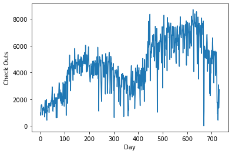

```python
from matplotlib import pyplot as plt
plt.plot(daily.loc[:,'day'], daily.loc[:,'cnt'])
plt.xlabel("Day")
plt.ylabel("Check Outs")
plt.show()
```

**Is there any correlation between temperature and the usage of bike-sharing services by casual checkout riders (users who use the service for a short period of time, on a one-time basis)?**

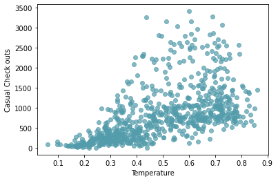

```python
# We will use a hex RGB string as the color
plt.scatter(daily.loc[:,'temp'] , daily.loc[:,'casual'], c = '#539cab', alpha = 0.7)
plt.xlabel("Temperature")
plt.ylabel("Casual Check outs")
plt.show()
```

**Now let's see if there is any correlation between temperature and the usage of bike-sharing services by registered checkout riders (users who have signed up for a subscription plan)?**

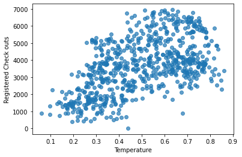

```python
plt.scatter(daily.loc[:,'temp'] , daily.loc[:,'registered'], c = '#1f77b4', alpha = 0.7)
plt.xlabel("Temperature")
plt.ylabel("Registered Check outs")
plt.show()
```

**Up to this point, it is evident that more people are using the ride-sharing service when the temperature is higher. However, we cannot conclusively determine if the correlation implies a causal relationship. Let's delve further into the data to gain a deeper understanding.**

## In-depth Analysis

**Does the type of checkout vary with temperature on working days and non-working days?**

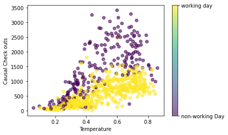

```python
plt.scatter(daily.loc[:,'temp'] , daily.loc[:,'casual'],  c = daily.loc[:,'workingday'], alpha = 0.6)
plt.xlabel("Temperature")
plt.ylabel("Causal Check outs")
cbar = plt.colorbar(ticks=[0, 1])
cbar.set_ticklabels(['non-working Day', 'working day'])
plt.show()
```

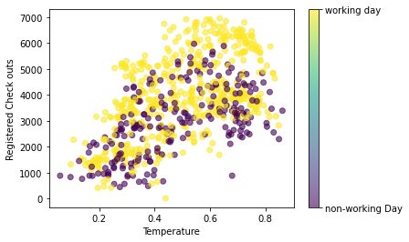

```python
plt.scatter(daily.loc[:,'temp'] , daily.loc[:,'registered'],  c = daily.loc[:,'workingday'], alpha = 0.6)
plt.xlabel("Temperature")
plt.ylabel("Registered Check outs")
cbar = plt.colorbar(ticks=[0, 1])
cbar.set_ticklabels(['non-working Day', 'working day'])
plt.show()
```

**Observation:**

### Customer Segmentation

1. Casual Users: These users predominantly utilize the bike-sharing service for leisure or recreational purposes. They are more likely to use the service on weekends and during their free time, seeking short-term trips or sightseeing opportunities.
2. Registered Users: This group consists of users who regularly use the service for commuting to various places. They have established accounts with the bike-sharing company and rely on the service for their daily transportation needs, indicating a consistent and frequent usage pattern.

By understanding these two customer segments, we can tailor our product offerings and marketing strategies to cater to their specific needs and preferences. The insights gained from customer segmentation can help us optimize the user experience and ensure that our bike-sharing service meets the diverse requirements of both casual and registered users effectively.

**Let's analyze which user base yields the highest profitability for the business.**

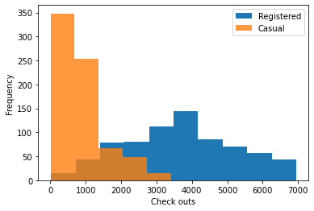

```python
plt.hist(daily.loc[:,'registered'], 10)
plt.hist(daily.loc[:,'casual'], 5, alpha = 0.8)
plt.xlabel("Check outs")
plt.ylabel("Frequency")
plt.legend(["Registered", "Casual"])
plt.show()
```

**Observation:**

The data analysis indicates that the majority of the user base consists of registered users, outweighing the number of casual users. By focusing on meeting the needs of registered users (discounted subscription fees, additional value-added services, increasing the number of bikes available at zones with higher user density, etc.) we can enhance customer satisfaction for a significant portion of our customer base, potentially leading to improved customer retention rates.

Furthermore, it is worth noting that many registered users might have initially started their journey with our service as casual users. Therefore, providing attractive promotional offerings to new users can serve as an excellent opportunity to make a positive first impression and attract potential customers, encouraging them to become loyal registered users in the long run. In addition, we can offer a customer-centric initiative, wherein customers can avail a 100% refund on their first two rides if they express dissatisfaction with the service and seek a reimbursement. This measure is designed to reinforce our commitment to user satisfaction and demonstrate confidence in the quality of our service. This move will also attract potential customers to try out the service, with a "nothing to lose" kind of mentality. They can experience the benefits and convenience of the offering without any financial risk, which can encourage them to explore the full potential of the product. By removing barriers and providing a risk-free opportunity, the initiative aims to build trust and establish a positive impression, ultimately fostering long-term customer relationships and loyalty.

**It's time to conduct a more comprehensive examination of the data. We will explore the seasonal data to gain further insights and potentially uncover valuable patterns and trends.**

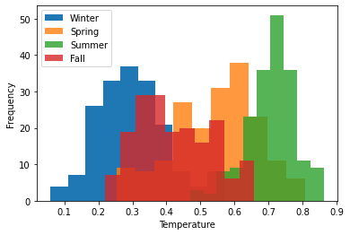

```python
Winter = daily.loc[ daily.loc[ :, 'season'] == 1 ,'temp']
Spring = daily.loc[ daily.loc[ :, 'season'] == 2 ,'temp']
Summer = daily.loc[ daily.loc[ :, 'season'] == 3 , 'temp']
Fall = daily.loc[ daily.loc[ :, 'season'] == 4 ,'temp']

plt.hist(Winter, 10)
plt.hist(Spring, 10, alpha = 0.8)
plt.hist(Summer, 10, alpha = 0.8)
plt.hist(Fall, 10, alpha = 0.8)
plt.xlabel("Temperature")
plt.ylabel("Frequency")
plt.legend(["Winter", "Spring", 'Summer', 'Fall'])
plt.show()
```

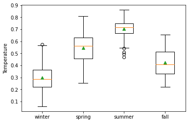

```
Mean temperature of each season:
Winter = 0.298
Spring = 0.544
Summer = 0.706
Fall = 0.423
```

```python
plt.boxplot( [Winter, Spring, Summer, Fall], showmeans = True)
plt.xticks( [1,2,3,4], ['winter', 'spring', 'summer', 'fall'])
plt.ylabel('Temperature')
plt.show()

import numpy as np
winter_tmpmean = np.mean(Winter)
spring_tmpmean = np.mean(Spring)
summer_tmpmean = np.mean(Summer)
fall_tmpmean = np.mean(Fall)

print(f'Mean temperature of each season:\nWinter ={winter_tmpmean: 0.3f}\nSpring ={spring_tmpmean: 0.3f}\nSummer ={summer_tmpmean: 0.3f}\nFall ={fall_tmpmean: 0.3f}')
```

**Is there any seasonal effect?**

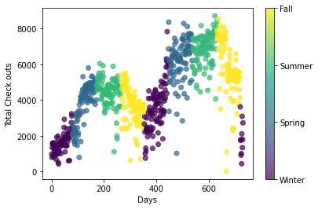

```python
plt.scatter(daily.loc[:,'day'], daily.loc[:,'cnt'], c = daily.loc[:,'season'], alpha = 0.7)
plt.xlabel("Days")
plt.ylabel("Total Check outs")
cbar = plt.colorbar(ticks=[1,2,3,4])
cbar.set_ticklabels(['Winter', 'Spring', 'Summer', 'Fall'])
plt.show()
```

**Observation:**

Yes, we can clearly observe a seasonal trend in the utilization of our bike-sharing services. The data reveals that during the winter season, specifically at the beginning and end of the year, we experience the lowest number of users. Conversely, as the weather transitions to summer, we observe the highest peak in service usage, followed by spring and fall.

## Correlation v/s Causation

In the initial stages of our data analysis, we noted a strong positive correlation between higher temperatures and increased usage of our product. However, upon further examination, it becomes apparent that the seasonal changes influence the temperature, subsequently impacting user purchasing behavior. The seasonal shifts lead to higher temperatures during summer, resulting in heightened demand for bike-sharing services, while the colder winter months deter users from frequent usage. Thus, it is essential to differentiate between correlation and causation to accurately interpret the factors influencing user behavior.

## How can we increase the profitability of the business during winter season?

To bolster the business's profitability during colder seasons, we can explore various strategies tailored to attract and retain customers despite the seasonal challenges:

1. Seasonal Promotions: Offer attractive discounts, special packages, or loyalty rewards during the winter season to incentivize more users to utilize the bike-sharing service. Providing cost-effective options during the off-peak season can attract customers and encourage them to continue using the service throughout the year.
2. Winter-specific Services: Introduce winter-specific services or features that cater to users' needs during colder months. For example, offer insulated accessories or weatherproof gear to enhance the comfort of riders during winter rides.
3. Indoor Facilities: Collaborate with local businesses, public spaces, or indoor venues to provide indoor bike parking or charging stations during winter. This allows users to conveniently access bikes without facing the challenges of inclement weather.
4. Partnerships with Businesses: Collaborate with local businesses or organizations to offer joint promotions or discounts, encouraging employees or customers to use the bike-sharing service for their daily commute or errands during winters.
5. Long-term Membership Benefits: Offer exclusive benefits or discounted rates for users who commit to long-term memberships or subscriptions. Providing incentives for extended commitments can help boost user retention during all seasons.
6. Data Analysis for Targeting: Utilize data analysis to identify areas or regions where winter bike-sharing demand may be higher. Focus marketing efforts and resource allocation on these areas to maximize returns.
7. User Surveys and Feedback: Conduct surveys and gather feedback from existing users to understand their preferences and pain points during the winter season. Use this insight to tailor services and improve the overall winter biking experience.